# Negative word of mouth can be a positive for consumers connected to the brand

Converted from PDF `Wilson-NegativeWOMBrandConnection-2017-JAMS.pdf` · 14 pages · anchors: page `#pN`, block `#pN-bK`

Page 1

ORIGINAL EMPIRICAL RESEARCH

## Negative word of mouth can be a positive for consumers connected to the brand

Andrew E. Wilson<sup>1</sup> & Michael D. Giebelhausen<sup>2</sup> & Michael K. Brady<sup>3</sup>

Received: 6 May 2014 /Accepted: 4 January 2017 /Published online: 1 February 2017 # Academy of Marketing Science 2017

Abstract It is widely accepted, and demonstrated in the marketing literature, that negative online word of mouth (NOWOM) has a negative impact on brands. The present research, however, finds the opposite effect among individuals who feel a close personal connection to the brand—a group that often contains the brand’s best customers. A series of three studies show that, when self–brand connection (SBC) is high, consumers process NOWOM defensively—a process that actually increases their behavioral intentions toward the brand. Study 1 demonstrates this effect using an experimental manipulation of SBC related to clothing brands, and provides process evidence by analyzing coded thought listings. Study 2 provides convergent evidence by measuring SBC associated with smartphones, and followup analyses show that as SBC increases, the otherwise negative effect of NOWOM steadily transforms to become significantly positive. Study 3 replicates these results using a combination of a national survey conducted by J.D. Power investigating hotel stays and data drawn from TripAdvisor. Results of all three studies, set in product

categories with varying levels of identity relevance, support the positive effects of NOWOM for high-SBC customers and have implications for both managers and researchers.

Keywords Complaining <sup>.</sup>Brand <sup>.</sup>User-generated content <sup>.</sup> Identity <sup>.</sup>Negative online word of mouth <sup>.</sup>Self–brand connection

Online word of mouth is increasingly being recognized as an issue of strategic importance for marketers, and managers are challenged to understand its influence on sales and other key outcome metrics (Kumar et al. 2016). According to a Mintel (2015) report, 70% of American consumers go online to seek out opinions related to goods and services prior to purchase. Correspondingly, Forbes magazine calls online word of mouth Bthe most important social media^ for marketers (Whitler 2014). The Marketing Science Institute’s 2014–16 Research Priorities classifies research addressing the question BHow do social media and digital technology change customer experiences and the consumer path to purchase?^ as a BTier 1 Priority^ (MSI.org 2014). The present research focuses on one particular aspect of how social media influences the path to purchase: exposure to negative online word of mouth (NOWOM)—wherein disgruntled individuals promote negative information about a brand in various online platforms.

It has long been established in the traditional WOM literature (e.g., Brown et al. 2005; De Matos and Rossi 2008; Duhan et al. 1997; Singh 1990) that negative WOM deserves particular attention due to its heavy influence on consumer judgments (Herr et al. 1991). This Bnegativity effect^ has also been demonstrated in online environments (for a review, see Verhagen et al. 2013). However, other researchers have questioned the prevalence of the negativity effect, noting that consumers evaluate such information through the lens of their

* Andrew E. Wilson andrew.wilson4@stmarys-ca.edu

Michael D. Giebelhausen mdg234@cornell.edu

Michael K. Brady mbrady@fsu.edu

1 School of Economics and Business Administration, Saint Mary’s College of California, 1928 Saint Mary’s Road, Moraga, CA 94556, USA

2 School of Hotel Administration, Cornell University, Ithaca, NY 14853, USA

3 College of Business, Florida State University, Tallahassee, FL 32306, USA

J. of the Acad. Mark. Sci. (2017) 45:534–547 DOI 10.1007/s11747-017-0515-z

Page 2

existing attitudes; notably, positive attitudes toward brands, which are known to attenuate the negativity effect (Ahluwalia 2000, 2002; Kirmani et al. 1999; Roehm and Brady 2007).

We extend this line of inquiry by examining how a consumer’s connection with a brand may go beyond merely attenuating the negative effects of NOWOM, and instead lead to a counterintuitive favorable effect. We argue that this contrary response is a consequence of self–brand connection (SBC; Escalas and Bettman 2003), which comes about as a result of consumers’ use of brands in accomplishing identityrelated goals, ultimately leading consumers to incorporate brands into their self-concepts. Following self–brand incorporation, negative information regarding that brand is viewed as a threat to the self (Cheng et al. 2012), which results in a psychological Bself-defense^ process whereby individuals cognitively combat the threatening information (Sherman and Cohen 2006). We further argue that such defensive processing of NOWOM results in a counterintuitive enhancement of behavioral intentions toward the brand. This is consistent with prior persuasion research that finds individuals with defensive motives process persuasion attempts defensively, leading to counterintuitive effects on attitudes (Liberman and Chaiken 1992; R. E. Petty and Cacioppo 1979).

The results of two lab studies and an industry survey are supportive of our theorizing. The first lab study manipulates SBC in the clothing category and finds that NOWOM interacts with SBC such that NOWOM has a positive effect for a brand with which the consumer is connected. Process evidence shows that consumers with a high SBC react as if they are personally under attack. In particular, they process the NOWOM Bdefensively^ by counter-arguing, derogating the message source, and re-affirming their own positive attitudes. Consistent with previous research on defensive information processing, we find that this response mediates the SBC × NOWOM interaction on behavioral intentions. In our second lab study, we sample from the population of Android smartphone owners and measure, rather than manipulate, SBC. Using a Johnson-Neyman procedure to probe the SBC × NOWOM interaction, we find that NOWOM has a negative effect at the lowest levels of SBC. However, as SBC increases, the effect of NOWOM steadily transforms to become significantly positive. In our field study, we utilize the same procedure to analyze data from the 2013 J.D. Power Guest Satisfaction Index—a study that collects over 400 measures from more than 60,000 consumers regarding a recent hotel stay. We pair these data with actual TripAdvisor ratings and observe, as might be expected, that the prevalence of negative reviews is negatively related to purchase intentions among low-SBC individuals. However, for individuals most committed to their hotel brand (the top 10%), we observe a positive relationship between the prevalence of NOWOM and behavioral intentions.

These findings have important implications for marketing managers seeking to adapt to the challenges of the digital media marketing environment (Fournier and Avery 2011), which go beyond traditional concerns to include even deliberate brand sabotage (Kähr et al. 2016). Specifically, our findings suggest that managers concerned about the effects of NOWOM on their brands’ health should consider incorporating SBC into their monitoring regime. Indeed, in part because high SBC may make brands more resilient to the negative effects of NOWOM, managers should consider strategies that generate high levels of SBC to be a key component of maintaining brand health. More generally, this research contributes to our understanding of an increasingly prevalent and important marketing phenomenon.

Research background

Consumer responses to negative information

The central question of the present research is whether (and how) strong self–brand connection leads consumers to defensively process NOWOM, leading in turn to counterintuitive favorable effects on purchase intentions. We see this question as important in part because ready access to online word of mouth has fundamentally changed the way consumers evaluate products and make purchase decisions (Mangold and Smith 2012). Conceptually, the question of how consumers respond to negative information has been studied both within and outside of the WOM literature. Within the WOM literature, we believe we are the first to study SBC as a key moderator of consumer responses to NOWOM, although there has been some suggestion that negative WOM may have positive effects when it is about the consumer’s main brand (East et al. 2008). We situate this research in a robust stream that has studied moderators of the effects of WOM, including characteristics of the consumer, the product, and the WOM itself. Table 1 presents a summary of the WOM literature by moderator variables. For reviews synthesizing what is (not) known about online word of mouth, see Rosario et al. (2016) and King et al. (2014).

In the most recent decade, much of the WOM literature has focused on online WOM, in part because the digital media environment has made the phenomenon much more measurable (Godes and Mayzlin 2004). Of course, WOM takes place offline as well, we also draw on numerous seminal works in that domain. For example, Richens’ (1983) examination was the first to illuminate factors that lead to negative word of mouth, including problem severity, perceptions of blame, and perceptions of retailer responsiveness. Later work pushed back against the notion that innovations would always diffuse through the marketplace via positive word of mouth (Mahajan et al. 1984) and established a strong link between perceived

J. of the Acad. Mark. Sci. (2017) 45:534–547 535

Page 3

Table 1 Word of mouth literature review by moderator variable

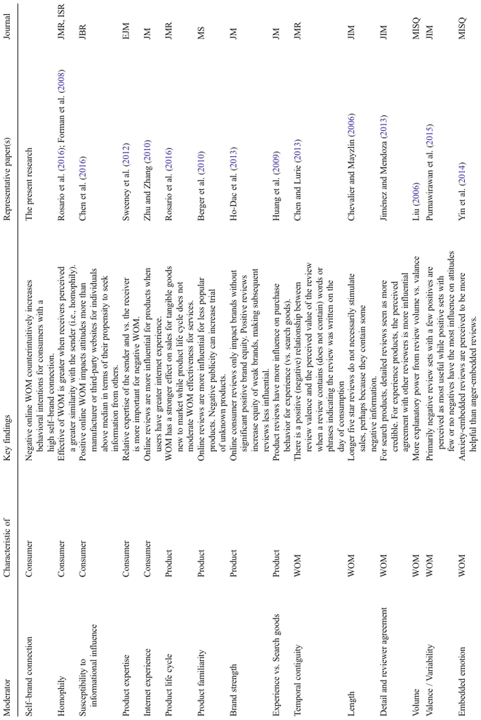

NOTE: complex table shown as an image of the PDF; the text below is a rough machine extraction and may be mis-aligned.

**extracted text (unreliable layout)**

536 J. of the Acad. Mark. Sci. (2017) 45:534–547

Page 4

justice and negative word of mouth intentions (Blodgett et al. 1993). With respect to positive word of mouth, links were established between positive WOM and service recovery efforts (Maxham 2001) and shared information (Brown and Reingen 1987). Building on the idea that WOM may not be the same across all formats, Herr et al. (1991) found that faceto-face (i.e., vivid) WOM was more persuasive than printed WOM. However, they also found that the advantage of faceto-face WOM was attenuated when: (1) a prior impression of the target brand was available from memory or (2) the information was very negative. This last result is particularly relevant to the present research, as it suggests negative WOM is perceived as highly diagnostic (and thus a salient threat to those with high self–brand connections).

In our reading of the extant literature, however, we note a striking lack of attention to the topic of how individual differences of the WOM receiver affect their response (See Table 1). Several papers have looked at homophily (i.e., the perceived similarity between the sender and the receiver), which is akin to an individual difference variable, and found that people are more influenced by reviews that originate from senders that seem similar to themselves (Rosario et al. 2016; Forman et al. 2008). Other studies have established connections between WOM and susceptibility to informational influence (Chen et al. 2016) and product expertise (Sweeney et al. 2014; Zhu and Zhang 2010). However, there is very little in the way of research that explores the attachments WOM receivers might have to a particular product or brand, and we were unable to locate any work that specifically examined the role of SBC in determining consumer response to NOWOM.

Turning to work outside the WOM literature, we find a number of papers examining conditions under which the effects of negative information on brand perceptions are buffered. Perhaps most relevant to the current research, Cheng et al. (2012) show a buffering effect of SBC on consumer self-esteem following exposure to negative information. However, the negative information Cheng et al. (2012) studied was relatively objective (expert reports of product failure), whereas we are studying the much more subjective information contained in consumer generated online WOM. We see this as a key reason why Cheng et al. (2012) find a buffering (rather than the counterintuitive reversal we predict), in that consumers should be more constrained in defensively processing objective negative information than they are in the case of the more subjective negative information under study here. Moreover, we see the subjective nature of NOWOM as a key aspect of understanding the phenomenon, in that the horizontal organization of the digital media environment represents an essential difference from the traditional media environment, which includes a more extensive role of experts and other gatekeepers (Tuten and Solomon 2015). Other

related research documents a Bblemishing effect^ whereby a small amount of weak negative information presented subsequent to positive information processed under low effort has a positive effect on purchase intentions (Ein-Gar et al. 2012). Prior work has also examined unsolicited recommendations from expert agents and found a reactance response under conditions where the expert recommends against a functionally dominant option (Fitzsimons and Lehmann 2004). However, we are aware of no prior work demonstrating a positive effect of NOWOM on behavioral intentions or delving into the process behind this counterintuitive effect, which is the purpose of our studies. We now turn to a discussion of the hypothesized process variable, self–brand connection.

Self–brand connection

Consumers’ self-concepts become intertwined with the products they consume (Sirgy 1982), and consumers’ acquisition of particular products can be motivated by a desire to construct, fine-tune, and present their self-concepts (Belk 1988). Similarly, consumers are known to purchase products with brand personalities that are similar to their own (Aaker 1997; Berger and Heath 2007) or that characterize a group to which they aspire (Escalas and Bettman 2005). Sometimes, however, brand attachments are less purposeful and emerge due to habit or circumstance (Schembri et al. 2010). Indeed, consumers can grow to Blove^ the brands they use to construct their identities (Batra et al. 2012; Ahuvia 2005) whereas, other times, brand relationships are more like a casual friendship (Fournier 1998). The net result is that, for any particular brand, the strength of consumers’ self–brand connection (SBC, Escalas and Bettman 2005) will range from very low to very high. It is important to point out that, quite often, it is easy for managers to target high-SBC consumers. These individuals often self-identify through their loyalty program status, membership in Bowners clubs,^ or heavy purchase behavior. Of primary interest to the present research is how those who feel most connected to a brand respond to NOWOM targeting that brand.

Defensive processing of NOWOM

A central proposition of the present research is that, when consumers are exposed to NOWOM about a brand to which they are highly connected, they will feel as if they themselves are under attack and will take steps to affirm their self-identities (Cheng et al. 2012). This line of reasoning is consistent with a large body of research suggesting that people are vigilant in their efforts to monitor the environment for threats to their self-integrity and have a Bpsychological immune system^ that launches into action when such a threat is perceived (Gilbert et al. 1998). Indeed, Dunning (2005) argues that consumer decision making is best described as a process of Bbelief harmonization^ where attitudes

J. of the Acad. Mark. Sci. (2017) 45:534–547 537

Page 5

are revised in order to affirm a flattering self-image. As such, marketers should evaluate their promotional efforts in terms of how they threaten or augment such beliefs.

Individuals’ motivation to actively defend the self from threat has been demonstrated in both the social psychology (e.g., Steele 1988) and consumer literatures (Chen et al. 2012). Individuals with defensive motives process persuasion attempts defensively in an attempt to resist such persuasion, which can lead to counterintuitive effects on attitudes (Liberman and Chaiken 1992; R. E. Petty and Cacioppo 1979). Defensive information processing can manifest in at least three distinct persuasion resistance tactics. First, individuals may simply affirm their own existing positive attitudes in response to negative persuasion attempts (Shin et al. 2014). Second, individuals may derogate the message source. For example, Laczniak et al. (2001) find that brand evaluations can be protected when individuals attribute word of mouth negativity to the communicator. Lastly, individuals may engage in counter-arguing, whereby the message recipient engages with the information by actively arguing against it. An outcome of the counter-arguing process is that individuals often emerge even more convinced of their original position (Liberman and Chaiken 1992; R. E. Petty and Cacioppo 1979).

In summary, building on prior work examining word of mouth, self–brand connection, and defense against self-threat, we expect the effect of NOWOM to be moderated by the degree to which a consumer feels connected to the targeted brand. Specifically, we expect that NOWOM will have a negative effect on behavioral intentions under conditions of low to moderate SBC and a counterintuitive positive effect when the NOWOM references a brand to which the individual feels a strong personal connection. Thus, we hypothesize:

H1: Self–brand connection and exposure to NOWOM related to that brand will have an interactive effect on consumers’ behavioral intentions, such that high (low)- SBC consumers will become more (less) inclined to purchase the brand following exposure. H2: The interaction of NOWOM exposure and self–brand connection specified in H1 will be mediated by defensive information processing.

We now subject these hypotheses to tests in a series of three studies, each in the context of different product categories: clothing (Study 1), smartphones (Study 2), and hotels (Study 3). Importantly, we selected these categories with the intent of studying our effects across categories that differed in terms of their identity relevance (Reed 2004). We assumed that clothing would be most identity-relevant, followed by smartphones, with hotels being the least so. To empirically validate this intuition, we conducted a test in which we recruited a sample of 100 participants on MTurk to rate clothing, smartphones, and hotels in terms of their sign value. For

example, BThe brand of __________ I choose shows what type of person I am^ (Kapferer and Laurent 1985). As expected, clothing was rated as having higher sign-value (M = 4.49) than smartphones (M = 3.79; p > .001), which was marginally higher than hotels (M = 3.54; p = .083).

Study 1: clothing

The primary goal of Study 1 is to demonstrate that NOWOM can have a positive effect on behavioral intentions when the NOWOM references a brand connected to the consumer’s self-concept. Additionally, Study 1 is designed to provide evidence that this effect will be driven by defensive information processing.

Method

Sample and design Study 1 was conducted in two phases. The first phase was used to elicit a favored (i.e., high SBC) clothing brand for each individual participant. Each participant was asked to rank 10 clothing brands (gathered in a pretest using an independent sample drawn from the same population). To avoid aspirational brands and the ceiling effects sometimes observed in this type of research (Ahluwalia 2000), the brand ranked fifth on each participant’s list became the target brand utilized in the stimuli for the second phase of the protocol.

In phase two, which occurred 10 to 14 days later, we randomly assigned participants to the conditions of a 2 (NOWOM: present vs. control) × 2 (SBC: high vs. low) between-participants factorial design. A total of 160 participants (99 female, 61 male) completed both phases of the study. An outlier analysis based on absolute value of standardized DFFIT revealed that no observations had undue influence (Cohen et al. 2002) and, thus, no responses were eliminated on this basis. Nine participants were eliminated following review of open-ended responses in which the participants expressed that the materials were not applicable to them. Further, the data for 12 participants were unusable due to a computer programming error (which prevented us from identifying the assigned condition), yielding a sample of 139 (88 female, 51 male). The stimuli for Study 1 consisted of an initial website that contained a positive promotional message and then a second website, which contained the NOWOM. For this study, the positive promotional message was an online advertisement for a shopping mall. This advertisement contained a promotional message for the participant’s target brand, as well as one sourced from an obscure Australian brand of clothing (Tsubi), which pretesting confirmed was unknown to the population. We felt this approach was superior to using a fictional brand where any promotional messaging we would create ourselves would likely not match the professionalism of that exhibited by an actual brand.

538 J. of the Acad. Mark. Sci. (2017) 45:534–547

Page 6

Participants were instructed to view the shopping mall website for as long as they needed to develop their impressions, and then to click a button to proceed. Participants in the NOWOM-present condition then proceeded to the NOWOM website, whereas the control participants proceeded directly to the questionnaire containing the dependent, demographic, and data quality measures. The NOWOM was based on an actual website, but adapted so that the content could apply to any of the 10 listed brands. The content of the NOWOM focused on how the target brand was overpriced given its quality, and that the maker was taking advantage of its customers’ need to fit in socially by charging such high prices. The target brand name was piped into the NOWOM in a procedure designed to make each version of the materials personally relevant to the individual participant.

Analysis

A 2 (NOWOM: present vs. absent) × 2 (SBC: high vs. low) ANOVA of behavioral intentions reveals a significant main effect of SBC (Mhigh-SBC = 4.48, Mlow-SBC = 2.45; F (1,135) = 63.59, p < .001), qualified by a significant SBC × NOWOM interaction (F (1, 135) = 7.37, p < .01). For participants exposed to online word of mouth about a favored clothing brand (i.e., the high-SBC condition), those exposed to NOWOM reported higher behavioral intentions (M = 4.89) than their unexposed counterparts (M = 4.07; F (1, 135 = 5.01, p < .05). For participants exposed to information about the obscure Australian brand (i.e., the low-SBC condition), NOWOM had a marginally negative effect on purchase intentions (MNOWOM-present = 2.16,

MNOWOM-absent = 2.73; F (1,135) = 2.56, p = .056). It is worth noting that a floor effect may be present in this comparison, as behavioral intentions, even in the NOWOM-absent conditions, were understandably low for the unknown Australian brand (M = 2.73). Figure 1 displays the conditional effects plot.

To provide insights into process, we conducted a conditional process analysis (Hayes 2013; Model 7), with NOWOM as the independent variable, behavioral intentions as the dependent variable, persuasion resistance as the mediator, and self– brand connection as the moderator of the path from NOWOM to persuasion resistance. This analysis reveals that, consistent with our theorizing, there was a significant NOWOM × SBC interaction in determining persuasion resistance (b = .712, t = 1.78, p < .05). The analysis also reveals a positive relationship between persuasion resistance and behavioral intentions (b = .355, t = 2.76, p < .01). Regarding the conditional effects, the relationship between NOWOM and behavioral intentions is moderated by SBC such that, for high-SBC participants, the effect’s 90% confidence interval (CI) does not include zero (LL = .065; UL = .817), though it did for their low-SBC counterparts. Furthermore, the index of moderated mediation, which is a test of equality of the conditional indirect effects across the two groups, is .253, and its 90% CI does not include zero (LL = .009; UL = .711). These results are consistent with a process whereby participants exposed to NOWOM about a brand to which they feel connected engaged in defensive information processing (leading to an increase in behavioral

Table 2 Measures

Behavioral intentions (Zeithaml et al. 1996)* If I needed a new [product], I would consider buying the brand I read about. I would tell my friends (who were looking for a new [product]) to consider the

brand I read about. If someone asked me, I would say that it is likely that I’d consider buying a new

smartphone of the brand I read about.

Behavioral intentions (J.D. Power 2013 GSI) † How likely are you to stay at this specific [Hotel] again How likely are you to recommend this specific [Hotel] to a friend, relative, or

colleague? Assuming that a [Hotel] is in the area, the next time you need to stay at a hotel, how

likely are you to stay at this hotel chain?

Self–brand connection (Escalas and Bettman 2003)* I feel a personal connection to this brand. This brand reflects who I am. I can identify with this brand. I use this brand to communicate who I am to other people. I think this brand helps me become the type of person I want to be. I consider this brand to be Bme^ (it reflects who I consider myself to be or the way

that I want to present myself to others). This brand suits me well.

Self–brand connection (J.D. Power 2013 GSI) ‡ I feel loyal to [Hotel] If I were unable to be a customer of [Hotel] I would be disappointed I am committed to [Hotel] I am proud to be a customer of [Hotel]

* Seven-point Likert format

† Four-point Definitely will not / Definitely will

‡Five-point Likert format

J. of the Acad. Mark. Sci. (2017) 45:534–547 539

Page 7

intentions), whereas those exposed to NOWOM about an identity-irrelevant brand did not.

Discussion

Study 1 finds that, for a brand connected to a consumer’s selfidentity, NOWOM has the counterintuitive effect of enhancing behavioral intentions toward the brand. Moreover, the results of the mediation analysis indicate that this enhancement of behavioral intentions operated via defensive information processing, in this case operationalized as the combination of counter-arguing, source derogation, and affirmations of positive attitude toward the brand. The analysis also shows that NOWOM had a marginally significant (p = .056) negative effect on behavioral intentions toward the unknown brand, to which our participants

would not have felt connected (i.e., the low-SBC condition). As mentioned above, since behavioral intentions for an unknown brand were understandably low to start with, a floor effect may have been partially responsible for this marginally significant result. Alternatively, involvement may have played a role, as participants in the Tsubi condition likely had little motivation to process information about an irrelevant brand. However, although the Tsubi conditions function as a useful counter-point (i.e., control condition) to the positive effect of NOWOM in the high-SBC condition, the primary focus of the present research is to demonstrate the potential for NOWOM to have a positive effect among high-SBC consumers. Thus, for the following studies, we will avoid the somewhat problematic task of manipulating SBC, and instead evaluate how individual differences in SBC interact with NOWOM in the context of a familiar brand.

Table 4 Intercorrelations, overall means, standard deviations, and discriminant validity estimates matrix

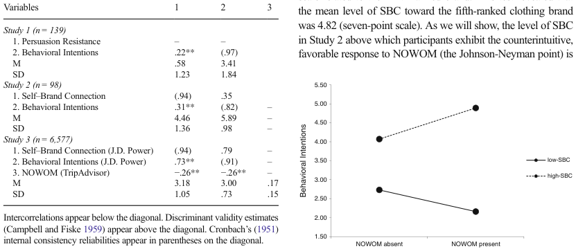

NOTE: complex table shown as an image of the PDF; the text below is a rough machine extraction and may be mis-aligned.

**extracted text (unreliable layout)**

** p < .01 (two-tailed)

* p < .05 (two-tailed)

Table 3 Descriptive statistics of persuasion resistance (Study 1)

[output not shown]

NOTE: table converted from PDF layout to HTML text; cell boundaries are reconstructed. See PDF if exact alignment matters.

CA = counter-arguing, SD = source derogation, PAA = positive attitude affirmation, PRSRSTS = persuasion resistance = (CA + SD + PAA)

Fig. 1 Effect of NOWOM on behavioral intentions at high and low SBC in clothing category (Study 1)

540 J. of the Acad. Mark. Sci. (2017) 45:534–547

Page 8

4.91, a very similar finding. Taken together, we interpret these results as support for the notion that participants in our high-SBC conditions are connected to the brand.

Study 2: smartphones

In Study 1, we presented mediation results indicating that, for a brand relevant to the participant’s self-concept, persuasion resistance led to increased behavioral intentions. While this result is supportive of our proposed process, several authors have argued that theoretically consistent interactions can be more effective than traditional mediation analyses for illuminating psychological processes (Spencer et al. 2005; Verlegh et al. 2013). In the present research, an interaction consistent with our proposed psychological process is one whereby, as self–brand connection increases, the effect of NOWOM on behavioral intentions becomes increasingly positive. In other words, we anticipate that higher levels of self-threat will result in higher levels of defense and, thus, higher behavioral intentions. Though often accomplished via median splits, a better analysis for demonstrating such an interaction is a Johnson- Neyman procedure. This procedure provides more robust process evidence by examining the slope of the relationship between the independent and dependent variable at all levels of the moderator (see Spiller et al. 2013 for a review), and so we employ it here.

Method

Procedure Participants were instructed to imagine they were shopping for a new smartphone, and that they were free to do so without contract termination charges or other barriers. All participants were then shown a mockup of an e-tailer product overview page (sourced from Amazon.com) that included a photo of a current-generation Android smartphone, along with product specifications, and a summary of consumer ratings (see Appendix). All participants were instructed to spend a

few minutes evaluating the page and were told that they would be asked questions about it later in the study. Participants in the NOWOM-absent condition then proceeded directly to the dependent, demographic, and data quality measures. Those in the NOWOM-present conditions, however, were first instructed to imagine that they read some of the reviews, and further, that though there are many reviews, one in particular Bcatches your eye.^ Participants were then presented the NOWOM manipulation, which consisted of a one-star rating, followed by a short paragraph that disparaged the Android brand on the basis that the Android brand was a copycat of Apple’s iOS brand, and that buyers were engaged in denial of their true wishes to own an iPhone. The content of the negative review was based upon common complaints observed in actual one-star reviews on Amazon.com.

Analysis

Discussion

The results of Study 2 provide additional support for the hypothesized interaction of NOWOM and SBC. Most relevant to the

J. of the Acad. Mark. Sci. (2017) 45:534–547 541

Page 9

present research, the results replicate the finding that, among high-SBC individuals, NOWOM increases behavioral intentions. Thus, Study 2 replicates the counterintuitive effects of NOWOM in a different product category, while measuring (rather than manipulating) self–brand connection. For those with low levels of self–brand connection, we again find that NOWOM has a negative effect. This result is consistent with Study 1 and builds upon previous research demonstrating the buffering effect of brand attitudes (Ahluwalia 2000; Kirmani et al. 1999; Roehm and Brady 2007). We now turn to a third study intended to extend our findings to industry data drawn from the travel sector.

Study 3: hotels

Online reviews are particularly important in the travel industry. The Oyster.com hotel review site summarizes the issue succinctly with their tagline BYou Can’t Return a Bad Vacation^ (Oyster.com 2015). Indeed, because travel products are typically expensive and often unfamiliar, online review websites such as TripAdvisor.com are consulted for the majority of hotel reservations, with 80% of consumers reading six to 12 reviews for each hotel purchase decision (hotelmarketing.com 2014). It is therefore reasonable to assume that, when making hotel reservations on a website that offers reviews, most individuals will pay at least some attention to those reviews.

For Study 3, we utilized data from the 2013 J.D. Power North American Hotel Guest Satisfaction Index (GSI) Study, which asks participants to describe a recent hotel stay on over 400 variables. Of particular interest were several variables that allowed us to select respondents who booked their hotel on a website that offers reviews. From an initial dataset of over 60,000 responses, we removed individuals who reported that they did not book the hotel room themselves (i.e., those reporting their reservation was made by a corporate travel department, assistant, family member). Next, we isolated individuals who booked their hotel reservation using an independent website that features online reviews (e.g. Expedia.com,

Hotels.com, Travelocity.com). This process resulted in a final sample size of 6,577 respondents who stayed at 4,661 different properties. To operationalize the extent to which the customer encountered NOWOM (our independent variable), a research assistant coded each of the 4,661 individual properties in terms of how many one-star, two-star, three-star, four-star, and fivestar reviews the property received on TripAdvisor.com. The proportion of negative ratings was then calculated for each property by adding the quantity of one-star and two-star ratings together and dividing by the total number of ratings. Although the resulting data do not allow us to know for certain whether an individual participant viewed the TripAdvisor.com ratings, the data do inform the likelihood that they did. Indeed, many travel reservation sites embed the actual TripAdvisor ratings (examples include Hotels.com, Expedia.com, and Travelocity.com). For reservation websites that feature proprietary reviews, we assume that their proportion of negative ratings will be correlated with those of TripAdvisor.com (to the extent that reviews reflect marketplace sentiment).

Measures

The J.D. Power GSI survey collected a three-item, four-point measure (α = .91) very similar to the three-item adaptation of Zeithaml et al. (1996) behavioral intentions measure utilized in our Studies 1 and 2. For instance, our measure read, BIf I needed a new smartphone, I would consider buying the brand I read about.^ The similar measure in the J.D. Power survey asked, BAssuming that a [Hotel] is in the area, the next time you need to stay at a hotel, how likely are you to stay at this hotel chain?^ The second item in the Study 1–2 scale read, BI would tell my friends (who were looking for a new smartphone) to consider the brand I read about.^ Similarly, the second item in the measure collected by the J.D. Power survey asked, BHow likely are you to recommend this specific [Hotel] to a friend, relative, or colleague?^ The J.D. Power survey also collected a four-item measure conceptually similar to self–brand connection. This five-point Likert scale measure asked participants to report their agreement with the following statements: (1) BI feel loyal to [Hotel],^ (2) BIf I were unable to be a customer of [Hotel] I would be disappointed,^ (3) BI am committed to [Hotel],^ and (4) BI am proud to be a customer of [Hotel]^ (α = .94).

[figure not shown]

NOTE: figure/graphic rendered as an image from the PDF; its content is not machine-readable text. Caption (if any) follows as the next block.

In order to evaluate the extent to which these apparently similar measures might be empirically equivalent (i.e., substitutable), we constructed an online survey consisting of the individual items used in these four scales, the only difference being that all items were adapted to a hotel context. We posted the survey on Amazon Mechanical Turk, with the headline BHave you stayed at a hotel in the past month?^ Two hundred and ninetytwo individuals completed all measures. Confirmatory factor analysis (CFA) was used to evaluate discriminant validity, per the recommendations of Fornell and Larcker (1981). With regard to self–brand connection, the results indicated that the

Fig. 2 Effect of NOWOM on behavioral intentions at high and low SBC among android smartphone users (Study 2)

542 J. of the Acad. Mark. Sci. (2017) 45:534–547

Page 10

square root of the average variance extracted (AVE) for both measures (.822, .826) was less than the correlation (.852) between the measures (see Table 5). This result indicates that the measures did not achieve discriminant validity and, thus, are substitutable. Similar results were observed for the behavioral intentions measures; that is, the square root of their AVE’s (.820, .895) were less than the intercorrelation of the two measures (.982). Again, this lack of discriminant validity, along with the very high correlations, suggest these measures are substitutable. Therefore, for each measure, we averaged the items and used these scores in an analysis replicating Study 2.

Analysis

We repeated the same Bfloodlight analysis^ (i.e., Johnson- Neyman procedure) conducted on the Study 2 data. As discussed above, this analysis leverages the Hayes (2013) PROCESS macro to examine the conditional effect of NOWOM (calculated as described above) across the entire range of SBC. Regarding the conditional effects, when self– brand connection was at its lowest (1 on a 5 point scale), we observe a significant negative effect of NOWOM on behavioral intentions (b = −.931, t = −11.355, p < .001; CI = −1.066 to −.796). As self–brand connection increases, the beta coefficient for NOWOM becomes less negative, becoming statistically insignificant at a self–brand connection of 3.842 (b = −.094, t = −1.645, p = .050; CI = −.188 to .000). At all levels of self– brand connection over 4.605 (9.7% of participants), the beta coefficient is significantly positive, maximizing at self–brand connection = 5 (b = .247, t = 2.670, p < .01; CI = .095 to .399).

Discussion

Study 3 utilizes data from a real-world consumption experience with a third product category to provide support for our hypothesis that NOWOM’s effect on behavioral intentions depends upon the connection consumers have with the brand. In particular, we find that a negative effect of NOWOM among low-SBC individuals grows progressively weaker and eventually flips to being positive as self–brand connection increases. However, while Study 3 contributes to the generalizability and ecological validity of the present research, it does

have some important limitations. First, although 80% of consumers report reading six to 12 reviews for each hotel purchase decision (hotelmarketing.com 2014), there was undoubtedly some portion of our Study 3 respondents who, although they booked their hotel online, did not view any reviews. Additionally, given the real-world nature of this data, it is possible that other mechanisms might have been operating.

To address these issues empirically, we conducted a brief followup study using an MTurk sample. Participants (n = 197) were randomly assigned to look up either a negative or positive review for a hotel they recently booked themselves using a travel website. This replicated the situation of the Study 3 participants (i.e., evaluating a hotel stay they booked themselves using an online website), but ensured that they were exposed to a review. After locating their hotel on Expedia.com, participants were instructed to (1) sort the reviews by lowest (highest) rating, (2) copy/paste the review at the top of the list into a text field on the survey, and (3) indicate the score associated with that rating. On the following page, participants were shown the review and asked to provide thoughts (one at a time) that crossed their mind while reading it. On the next page, participants reported their behavioral intentions and then completed an individual reactance scale, so that we might evaluate this as a potential moderator. Lastly, participants were shown their thoughts one at a time and asked to categorize them as (1) questioning or arguing against the review, (2) agreeing with the review, (3) questioning the credibility of the person posting the review, (4) having positive thoughts about the hotel, (5) having negative thoughts about the hotel, or (6) other. As in Study 1, the extent of defensive information processing was computed as counter-arguing plus source derogation plus positive attitude expressions.

Replicating Study 1, a conditional process analysis (Hayes 2013; Model 7) with NOWOM (0/1) as the independent variable, behavioral intentions as the dependent variable, persuasion resistance as the mediator, and SBC as the moderator indicates an interaction of SBC and NOWOM in determining defensive information processing (b = .304, t = 3.56, p < .001), along with a positive relationship between defensive information processing and behavioral intentions (b = .236, t = 1.85, p = .066). Consistent with our theorizing, for high-SBC participants (+1 SD), the 90% confidence interval (CI) does not

Table 5 CFA to demonstrate JDP measure equivalence / substitutability

[output not shown]

NOTE: table converted from PDF layout to HTML text; cell boundaries are reconstructed. See PDF if exact alignment matters.

The bolded diagonal cells contain the square roots of the AVE’s. The off-diagonal cells contain the measure correlations. The italicized cells highlight comparisons relevant to measure substitutability (i.e., correlation > square root of AVE), where the superscripts a and b indicate the cells used in each comparison.

EB = Escales and Bettman 2003; ZBP = Zeithaml, Berry, and Parasuraman 1996; JDP = J.D. Power

J. of the Acad. Mark. Sci. (2017) 45:534–547 543

Page 11

include zero (LL = .025; UL = .455) whereas it did include zero for those with a low self–brand connection (-1 SD). The index of moderated mediation does not include zero (LL = .009; UL = .173). A second analysis indicates there was no reactance × NOWOM interaction in determining defensive information (p = .301), suggesting that reactance was not driving the effect. However, consistent with our hypotheses, there is a significant SBC × NOWOM interaction in determining defensive information processing (p < .01). In sum, although the J.D. Power survey did not include a measure of defensive information processing, this followup study provides support for the notion that this process contributed to the observed effects.

General discussion

The present research examines the effect of negative online word of mouth (NOWOM) on consumers’ behavioral intentions (e.g., repurchase) toward the targeted brand. Contrary to conventional expectations, across three studies we observe an effect whereby exposing consumers with a high self–brand connection to NOWOM increases their behavioral intentions toward the brand. This SBC × NOWOM interaction is consistent with a process involving defensive information processing. Additional evidence of defensive information processing is provided by two conditional process analyses demonstrating that high-SBC participants react defensively to NOWOM by derogating the source of the message, counter-arguing, and generally re-affirming their prior positive attitudes. From a theoretical perspective, this research adds to our understanding of how social media affects a consumer’s path to purchase.

This research also has a number of implications for marketing practice. For example, small and midsize businesses spend in excess of $700 million per year on online reputation management services, many of which falsely claim that they can remove negative customer reviews (Loten 2012). The results of our studies suggest that such reviews can have counterintuitive, positive effects on consumers with strong SBC and, hence, given a fixed set of resources, managers may weigh the alternative of investing in brand building actions designed to generate SBC rather than investments aimed at

preventing NOWOM exposure. Moreover, because NOWOM has differential effects on high- and low-SBC consumers, reputation management resources may be prioritized for websites frequented by less loyal customers (e.g., third-party sites) in favor of those frequented by more loyal customers (e.g., brand-owned sites). Additionally, firms should consider studying the SBC levels of their customer base as a part of strategic decisions about investing in online reputation management. To the extent that a firm’s customers are primarily high SBC individuals, the most prudent course may be to direct these resources elsewhere.

Furthermore, our results indicate that the size of high (low)- SBC segments may vary substantially by product category. Managers should study the distribution of SBC in their own category to further understand how their customers and prospects may respond to NOWOM. Finally, online retailers might leverage these results to deliver more effective promotions. For example, online retailers will often possess potential behavioral indicators of self–brand connection (e.g., frequent purchase) and they also often know when a visitor has been exposed to a negative review. Such a combination could indicate an increased level of purchase readiness, and thereby trigger closing tactics (e.g., a remarketing banner ad).

Additionally, for Studies 1 and 2, consumers were exposed to only a single review. While it can be argued that this makes for a conservative test of our counterintuitive favorable effect

544 J. of the Acad. Mark. Sci. (2017) 45:534–547

Page 12

hypothesis, it is probably more typical for consumers to be exposed to more than one review at a time. One avenue for future research would be to present high- and low-SBC consumers with a set of reviews and vary the number and proportion that were positive vs. negative. Additionally, one might also expose the consumer to multiple NOWOM messages over a period of time. Given the results of our field study, we would not expect drastically different findings. However, further investigation of how SBC and review set interact would represent a valuable extension. Another avenue for future research would be to manipulate the strength of the argument. For example, it would be interesting to see how high-SBC consumers would respond to NOWOM that cites academic research or consumer reports, as compared with the more subjective consumer opinion studied here. Future

research might also want to examine low-SBC individuals and what factors make NOWOM more influential for this group. For example, in Study 2 we examined smartphones—a product with a relatively high switching cost. Presumably, in situations characterized by low SBC and low switching costs, NOWOM will have a larger negative effect. Alternatively, one might conceptualize the number of reviews consumed (i.e., read) as the dependent variable and then test whether SBC is predictive of review consumption, and also how review valence might moderate this relationship. One would imagine that high-SBC individuals might read a larger number of positive reviews (as these reviews bolster their self-concept), but might stop reading after encountering a single negative review (as these types of reviews represent a threat to their self-concepts).

Appendix

Study 2 Stimulus

Product overview page (shown to all participants)

[figure not shown]

NOTE: figure/graphic rendered as an image from the PDF; its content is not machine-readable text. Caption (if any) follows as the next block.

NOWOM (shown to only NOWOM-present participants)

J. of the Acad. Mark. Sci. (2017) 45:534–547 545

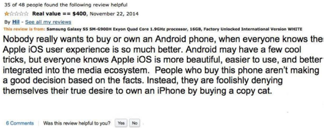

NOTE: figure/graphic rendered as an image from the PDF; its content is not machine-readable text. Caption (if any) follows as the next block.

Page 13

References

Aaker, J. L. (1997). Dimensions of Brand Personality. Journal of

Marketing Research, 34, 347–356. Ahluwalia, R. (2000). Examination of psychological processes underly-

ing resistance to persuasion. Journal of Consumer Research, 27, 217–232. Ahluwalia, R. (2002). How prevalent is the negativity effect in consumer

environments? Journal of Consumer Research, 29, 270–279. Ahuvia, A. C. (2005). Beyond the extended self: Loved objects and

consumers’ identity narratives. Journal of Consumer Research, 32, 171–184. Batra, R., Ahuvia, A., & Bagozzi, R. P. (2012). Brand Love. Journal of

Marketing, 76(2), 1–16. Belk, R. (1988). Possessions and self. John Wiley & Sons, Ltd. Berger, J., & Heath, C. (2007). Where consumers diverge from others:

Identity signaling and product domains. Journal of Consumer Research, 34, 121–134. Berger, J., Sorensen, A. T, & Rasmussen, S. J. (2010). Positive effects of

negative publicity: when negative reviews increase sales. Marketing Science, 29(5), 815–827. Blodgett, J. G., Granbois, D. H., & Walters, R. G. (1993). The effects of

perceived justice on complainants’ negative word-of-mouth behavior and repatronage intentions. Journal of Retailing, 69(4), 399–428. Brown, J. J., & Reingen, P. H. (1987). Social ties and word-of-mouth

referral behavior. Journal of Consumer Research, 14(3), 350–362. Brown, T. J., Barry, T. E., Dacin, P. A., & Gunst, R. F. (2005). Spreading

the word: Investigating antecedents of consumers’ positive word-ofmouth intentions and behaviors in a retailing context. Journal of the Academy of Marketing Science, 33, 123–138. Campbell, D. T., & Fiske, D. W. (1959). Convergent and discriminant

validation by the multitrait-multimethod matrix. Psychological Bulletin, 56(2), 81–105. Chen, Z. & Lurie, N. H. (2013). Temporal contiguity and negativity bias

in the impact of online word of mouth. Journal of Marketing Research, 50(4), 463–476. Chen, J., Teng, L., Yu, Y, & Yu, X. (2016). The effect of online informa-

tion sources on purchase intentions between consumers with high and low susceptibility to informational influence. Journal of Business Research, 69(2), 467–475. Cheng, S. Y., White, T. B., & Chaplin, L. N. (2012). The Effects of Self-

Brand Connections on Responses to Brand Failure: A New Look at the Consumer–Brand Relationship. Journal of Consumer Psychology, 22, 280–288. Chevalier, J. A., & Mayzlin, D. (2006). The effect of word of mouth on

sales: Online book reviews. Journal of Marketing Research, 43(3), 345–354. Cohen, J., Cohen, P., West, S. G., & Aiken, L. S. (2002). Applied Multiple

Regression/Correlation. Mahwah, NJ: Erlbaum. Cronbach, L. J. (1951). Coefficient alpha and the internal structure of

tests. Psychometrika, 16(3), 297–334. De Matos, C. A., & Rossi, C. A. V. (2008). Word-of-mouth communications

in marketing: a meta-analytic review of the antecedents and moderators. Journal of the Academy of Marketing Science, 36, 578–596. Duhan, D. F., Johnson, S. D., Wilcox, J. B., & Harrell, G. D. (1997).

Influences on consumer use of word-of-mouth recommendation sources. Journal of the Academy of Marketing Science, 25, 283– 295. Dunning, D. (2005). Self-image motives and consumer behavior: How

sacrosanct self-beliefs sway preferences in the marketplace. Journal of Consumer Psychology, 17, 237–249. East, R., Hammond, K., & Lomax, W. (2008). Measuring the impact of

positive and negative word of mouth on brand purchase probability. International Journal of Research in Marketing, 25, 215–224.

Ein-Gar, D., Shiv, B., & Tormala, Z. L. (2012). When blemishing leads to

blossoming: The positive effect of negative information. Journal of Consumer Research, 38(5), 846–859. Escalas, J., & Bettman, J. R. (2003). You Are What They Eat: The

Influence of Reference Groups on Consumers’ Connections to Brands. Journal of Consumer Psychology, 13, 339–348. Escalas, J. E., & Bettman, J. R. (2005). Self-construal, reference groups,

and brand meaning. Journal of Consumer Research, 32(3), 378– 389. Fitzsimons, G. J., & Lehmann, D. R. (2004). Reactance to recommenda-

tions: When unsolicited advice yields contrary responses. Marketing Science, 23, 82–94. Forman, C., Ghose, A., & Wiesenfeld, B. (2008). Examining the relationship

between reviews and sales: the role of reviewer identity disclosure in electronic markets. Information Systems Research, 19(3), 291–313. Fornell, C., & Larcker, D. F. (1981). Evaluating structural equation

models with unobservable variables and measurement error. Journal of Marketing Research, 18, 39–50. Fournier, S. (1998). Consumers and their brands: Developing relationship

theory in consumer research. Journal of Consumer Research, 24, 343–353. Fournier, S., & Avery, J. (2011). The uninvited brand. Business Horizons,

54(3), 193–207. Gilbert, D. T., Pinel, E. C., Wilson, T. D., Blumberg, S. J., & Wheatley, T. P.

(1998). Immune neglect: a source of durability bias in affective forecasting. Journal of Personality and Social Psychology, 75(3), 617. Godes, D., & Mayzlin, D. (2004). Using online conversations to study

word-of-mouth communication. Marketing Science, 23(4), 545–560. Hayes, A. F. (2013). Introduction to mediation, moderation, and condition-

al process analysis: A regression-based approach. Guilford Press. Herr, P. M., Kardes, F. R., & Kim, J. (1991). Effects of word-of-mouth

and product-attribute information on persuasion: An accessibilitydiagnosticity perspective. Journal of Consumer Research, 17(4), 454–462. Ho-Dac, N. N., Carson, S. J., & Moore W. L. (2013). The effects of

positive and negative online customer reviews: do brand strength and category maturity matter? Journal of Marketing, 77(6), 37–53. Huang, P., Lurie, N. H. & Mitra, S. (2009). Searching for experience on

the web: an empirical examination of consumer behavior for search and experience goods. Journal of Marketing, 73(2), 55–69. Jiménez, F. R., & Mendoza, N. A. (2013). Too popular to ignore: the

influence of online reviews on purchase intentions of search and experience products. Journal of Interactive Marketing, 27(3), 226–235. Kähr, A., Nyffenegger, B., Krohmer, H., & Hoyer, W. D. (2016). When

hostile consumers wreak havoc on your brand: the phenomenon of consumer brand sabotage. Journal of Marketing, 80(3), 25–41. Kamins, M. A., & Assael, H. (1987). Two-sided versus one-sided ap-

peals: A cognitive perspective on argumentation, source derogation, and the effect of disconfirming trial on belief change. Journal of Marketing Research, 24(1), 29–39. Kapferer, J. N., & Laurent, G. (1985). Consumer involvement profiles: a

new and practical approach to consumer involvement. Journal of Advertising Research, 25, 48–56. King, R. A., Racherla, P., & Bush, V. D. (2014). What we know and don’t

know about online word-of-mouth: A review and synthesis of the literature. Journal of Interactive Marketing, 28(3), 167–183. Kirmani, A., Sood, S., & Bridges, S. (1999). The ownership effect in re-

sponses to brand line stretches. Journal of Marketing, 63(1), 88–101. Kumar, V., Choi, J.B., & Greene, M. (2016). Synergistic effects of social

media and traditional marketing on brand sales: capturing the timevarying effects. Journal of the Academy of Marketing Science, forthcoming. Laczniak, R. N., DeCarlo, T. E., & Ramaswami, S. N. (2001). Consumers’

responses to negative word-of-mouth communication: An attribution theory perspective. Journal of Consumer Psychology, 11, 57–73.

546 J. of the Acad. Mark. Sci. (2017) 45:534–547

Page 14

Liberman, A., & Chaiken, S. (1992). Defensive Processing Of Personally

Relevant Health Messages. Personality and Social Psychology Bulletin, 18, 669–679. Liu, Y. (2006). Word of mouth for movies: Its dynamics and impact on

box office revenue. Journal of Marketing, 70(3), 74–89. Loten, A (2012). Hoping to fix bad reviews? Not so fast. Wall Street

Journal, available online at http://www.wsj.com/articles/ ?SB10000872396390444840104577548982072928526. Mahajan, V., Muller, E., & Kerin, R. A. (1984). Introduction strategy for

new products with positive and negative word-of-mouth. Management Science, 30(12), 1389–1404. Mangold, G., & Smith, K. T. (2012). Selling to millennials with online

reviews. Business Horizons, 55(2), 141–153. Maxham, J. G. (2001). Service recovery’s influence on consumer satis-

faction, positive word-of-mouth, and purchase intentions. Journal of Business Research, 54(1), 11–24. Mintel.com (2015). Seven in 10 Americans Seek out Opinions Before

Making Purchases, October 1, Retrieved from http://www.mintel. com/press-centre/social-and-lifestyle/seven-in-10-americans-seekout-opinions-before-making-purchases. MSI.org (2014). 2012–2016 Research Priorities. October 2, retrieved

from http://www.msi.org/research/2014-2016-research-priorities/. Petty, R. E., & Cacioppo, J. T. (1979). Effects of forewarning of persua-

sive intent and involvement on cognitive responses and persuasion. Personality and Social Psychology Bulletin, 5, 173–176. Purnawirawan, N., Eisend, M., De Pelsmacker, P., & Dens, N. (2015). A

meta-analytic investigation of the role of valence in online reviews. Journal of Interactive Marketing, 31, 17–27. Reed, A. (2004). Activating the self-importance of consumer selves: ex-

ploring identity salience effects on judgments. Journal of Consumer Research, 31(2), 286–295. Richins, M. L. (1983). Negative word-of-mouth by dissatisfied con-

sumers: A pilot study. Journal of Marketing, 47(1), 68–78. Roehm, M. L., & Brady, M. K. (2007). Consumer Responses to

Performance Failures by High-Equity Brands. Journal of Consumer Research, 34(December), 537–545. Rosario, A. B., Sotgiu, F., De Valck, K., & Bijmolt, T. H. A. (2016). The

effect of electronic word of mouth on sales: A meta-analytic review of platform, product, and metric factors. Journal of Marketing Research, 53(3), 297–318. Schembri, S., Merrilees, B., & Kristiansen, S. (2010). Brand consumption

and narrative of the self. Psychology and Marketing, 27, 623–637. Sherman, D. K., & Cohen, G. L. (2006). The psychology of self‐defense:

Self‐affirmation theory. Advances in Experimental Social Psychology, 38, 183–242.

Shin, D., Song, J. H., & Biswas, A. (2014). Electronic word-of-

mouth (eWOM) generation in new media platforms: The role of regulatory focus and collective dissonance. Marketing Letters, 25(2), 153–165. Singh, J. (1990). Voice, exit, and negative word-of-mouth behaviors: an

investigation across three service categories. Journal of the Academy of Marketing Science, 18, 1–15. Sirgy, M. J. (1982). Self-Concept in Consumer Behavior: A critical

Review. Journal of Consumer Research, 9, 287–300. Spencer, S. J., Zanna, M. P., & Fong, G. T. (2005). Establishing a causal

chain: why experiments are often more effective than mediational analyses in examining psychological processes. Journal of Personality and Social Psychology, 89(6), 845–851. Spiller, S. A., Fitzsimons, G. J., Lynch, J. G., Jr., & McClelland, G. H.

(2013). Spotlights, floodlights, and the magic number zero: Simple effects tests in moderated regression. Journal of Marketing Research, 50, 277–288. Steele, C. M. (1988). The psychology of self-affirmation: Sustaining the

integrity of the self. Advances in Experimental Social Psychology, 21, 261–302. Sweeney, J., Soutar, G., & Mazzarol, T. (2014). Factors enhancing word-

of-mouth: positive and negative service-related messages. European Journal of Marketing, 48(1/2), 336–359. Tuten, T. L., & Solomon, M. (2015). Social Media Marketing (2nd ed.).

Los Angeles: Sage. Verhagen, T., Nauta, A., & Feldberg, F. (2013). Negative online word-of-

mouth: Behavioral indicator or emotional release? Computers in Human Behavior, 29, 1430–1440. Verlegh, P. W. J., Ryu, G., Tuk, M. A., & Feick, L. (2013). Receiver

responses to rewarded referrals: the motive inferences framework. Journal of the Academy of Marketing Science, 41(6), 669–682. Whitler, K. A. (2014). Why word of mouth is the most important social

media. Forbes, July 17, 2014. Wright, P. L. (1973). The cognitive processes mediating acceptance of

advertising. Journal of Marketing Research, 10(1), 53–62. Yin, D. Z., Bond, S. D. & Zhang, H. (2014) Anxious or angry? Effects of

discrete emotions on the perceived helpfulness of online reviews. MIS Quarterly, 38(2), 539–560. Zeithaml, V. A., Berry, L. L., & Parasuraman, A. (1996). The Behavioral

Consequences of Service Quality. Journal of Marketing, 60, 31–47. Zhu, F., & Zhang, X. (2010). Impact of online consumer reviews on sales:

the moderating role of product and consumer characteristics. Journal of Marketing, 74(2), 133–148.

J. of the Acad. Mark. Sci. (2017) 45:534–547 547